# **CMU 16825 Learning for 3D Vision – Assignment 2 Submission**

## Task 2.3: Image to mesh (20 points)

The following shows the input RGB image, the ground truth mesh, and the render of predicted mesh:

Input RGB Image

Ground Truth Mesh

Predicted Mesh

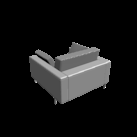

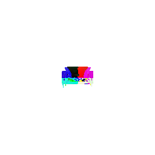

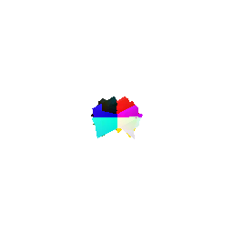

Input RGB Image

Ground Truth Mesh

Predicted Mesh

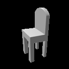

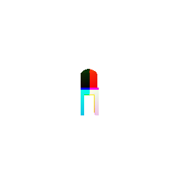

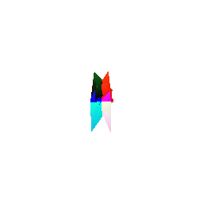

Input RGB Image

Ground Truth Mesh

Predicted Mesh

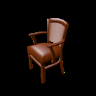

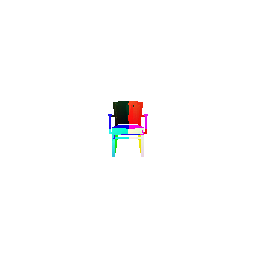

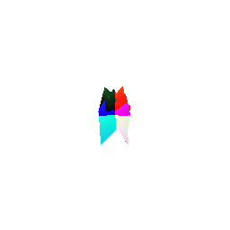

## Task 2.4: Quantitative comparisions(10 points)

The following shows a table of three evalution plots for the reconstruction of voxels, point clouds, and meshes from single RGB input images.

Voxel Evaluation

Point Cloud Evaluation

Mesh Evaluation

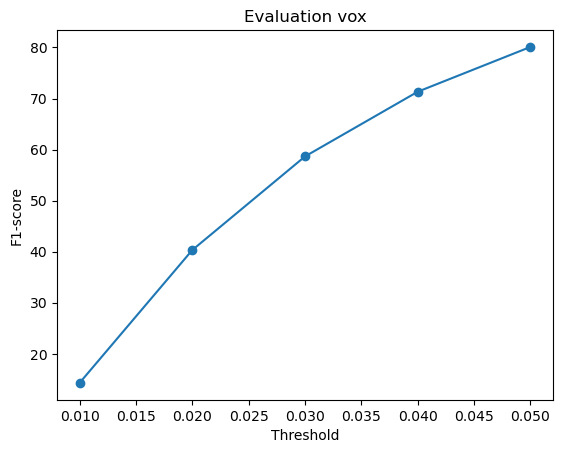

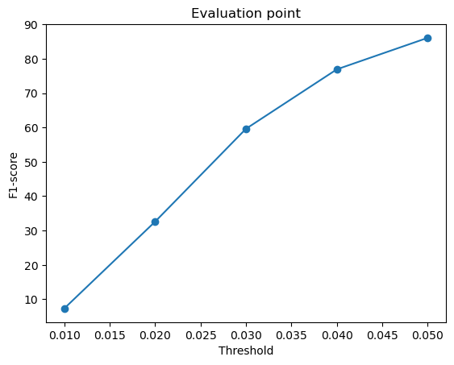

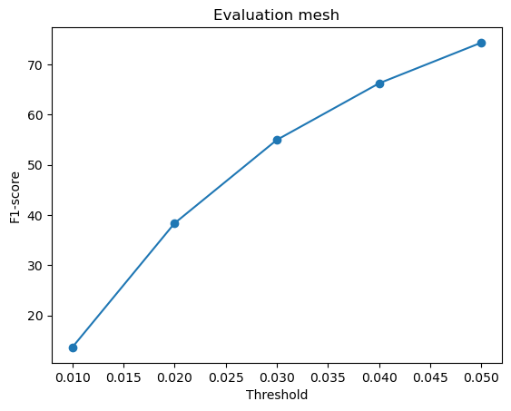